# Loan Data from Prosper

## by Ali Shaker

## Investigation Overview

> What affects the borrower’s APR or interest rate?

## Dataset Overview

> This data set contains 113,937 loans with 81 variables on each loan, including loan amount, borrower rate (or interest rate), current loan status, borrower income, and many others.

### What is/are the main feature(s) of interest in your dataset?

> feature that affect the loan’s outcome status and that affect the borrower’s APR or interest rate

### What features in the dataset do you think will help support your investigation into your feature(s) of interest?

> i think the IncomeRange will affect on the borrower’s APR or interest rate

## Univariate Exploration

## We will start by the categorical variables analysis

### Let's look at the ranges of the income for all the borrowers

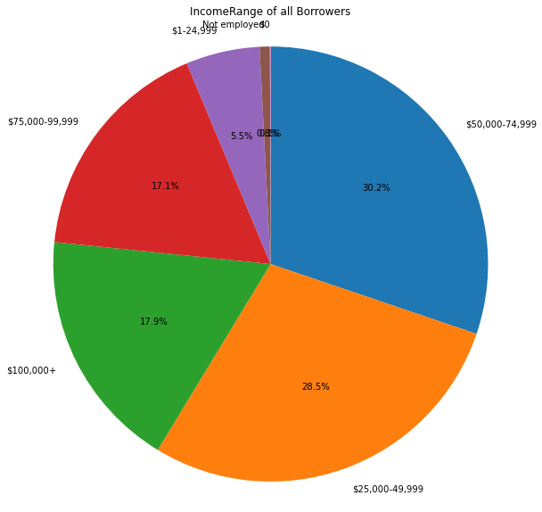

```python
plt.figure(figsize = [20, 10])
sorted_counts = df2['IncomeRange'].value_counts()
plt.pie(sorted_counts, labels = sorted_counts.index, startangle = 90,
        counterclock = False, autopct   = '%.1f%%');
plt.title("IncomeRange of all Borrowers")
plt.axis('square');
```

#### Most Borrowers have an income range 50000 - 74999 USD

### let's look at the Term counts

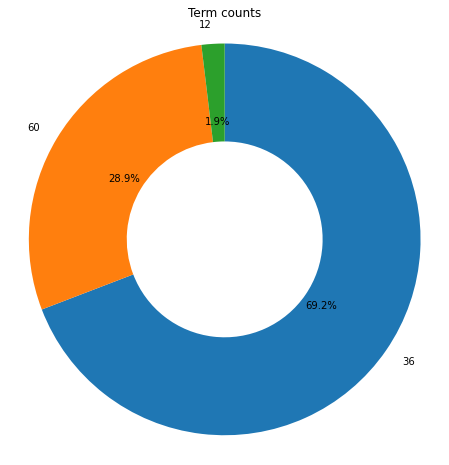

```python
plt.figure(figsize = [15, 8])
NDF = df2['Term'].value_counts()
plt.pie(NDF, labels = NDF.index, startangle = 90,
        counterclock = False, wedgeprops = {'width' : 0.5}, autopct   = '%.1f%%');
plt.title("Term counts")
plt.axis('square');
```

#### most of borrwers take the loan with term 36 monthes and the least of them take it with term 12 monthes

## The Insights of categorical variables analysis :

> Most Borrowers have an income range 50000 - 74999 USD

> most of borrwers take the loan with term 36 monthes and the least of them take it with term 12 monthes

## Now we will start to Analyze the numeric attributes

### Let's look at the Borrower's Annual Percentage Rate (APR) for the loan.

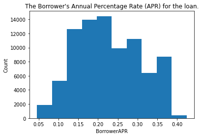

```python
plt.hist(data = df2, x = 'BorrowerAPR');
plt.xlabel('BorrowerAPR');
plt.ylabel('Count');
plt.title("The Borrower's Annual Percentage Rate (APR) for the loan.");
```

### Let's look at the Loan Original Amount of all Borrowers

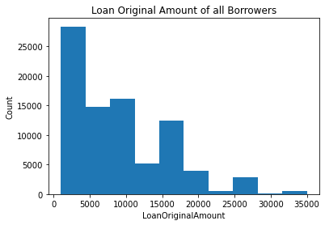

```python
plt.hist(data = df2, x = 'LoanOriginalAmount');
plt.xlabel('LoanOriginalAmount');
plt.ylabel('Count');
plt.title("Loan Original Amount of all Borrowers");
```

the histgram is right skewed

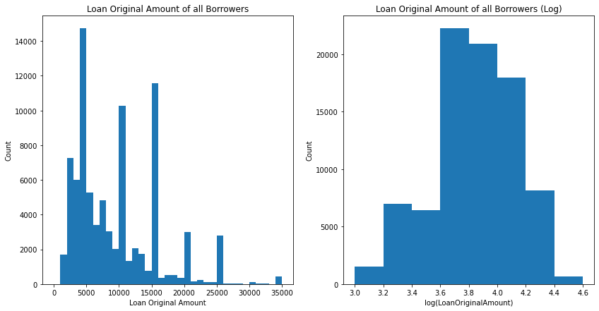

```python
plt.figure(figsize = [14, 7])

# left histogram: data plotted in natural units
plt.subplot(1, 2, 1)
bin_edges = np.arange(0, df2.LoanOriginalAmount.max()+1000, 1000)
plt.hist(data =df2, x = 'LoanOriginalAmount', bins = bin_edges)
plt.xlabel('Loan Original Amount')
plt.ylabel('Count');
plt.title("Loan Original Amount of all Borrowers");

# right histogram: data plotted after direct log transformation
plt.subplot(1, 2, 2)
log_data = np.log10(df2.LoanOriginalAmount)
log_bin_edges = np.arange(3.0, log_data.max()+0.1, 0.2)
plt.hist(log_data, bins = log_bin_edges)
plt.xlabel('log(LoanOriginalAmount)');
plt.ylabel('Count');
plt.title("Loan Original Amount of all Borrowers (Log)");

df2.LoanOriginalAmount_log = np.log10(df2.LoanOriginalAmount)
```

#### Loan Original Amount started from 1000 to 35000 and there are multiple peaks observed at 4000 , 10000 and 15000 $.

### Let's look at the monthly loan payment for all borrowers

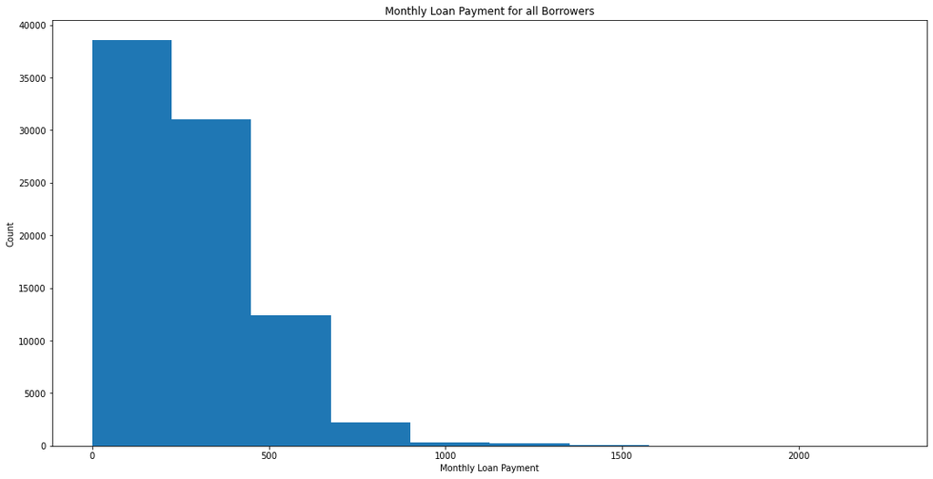

```python
plt.figure(figsize = [18, 9])
plt.hist(data = df2, x = 'MonthlyLoanPayment');
plt.xlabel('Monthly Loan Payment');
plt.ylabel('Count');
plt.title("Monthly Loan Payment for all Borrowers");
```

#### Most of borrowers pay less than 500 USD monthly for the loan

### Discuss the distribution(s) of your variable(s) of interest. Were there any unusual points? Did you need to perform any transformations?

> i need to make transformations for the variables (Investors , LoanOriginalAmount)

### Of the features you investigated, were there any unusual distributions? Did you perform any operations on the data to tidy, adjust, or change the form of the data? If so, why did you do this?

> changed the columns names that contain a white space to can work on them

> changed the data type of the Term variable to be category instead of int64

> drop all rows that contain NULL values

## The Insights of Numerical variables analysis :

> Loan Original Amount started from 1000 to 35000 and there are multiple peaks observed at 4000 , 10000 and 15000 USD

> Most of borrowers pay less than 500 USD monthly for the loan

## Bivariate Exploration

## Categorical Vs Numeric

### Check if the IncomeRange will affect on the borrower’s APR or not

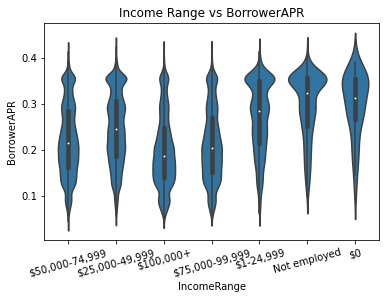

```python
base_color = sb.color_palette()[0]
sb.violinplot(data = df2, x = 'IncomeRange', y = 'BorrowerAPR', color = base_color)
plt.xticks(rotation = 15);
plt.title('Income Range vs BorrowerAPR')
```

## Numeric Vs Numeric

### Check if the LoanOriginalAmount will affect on the borrower’s APR or not

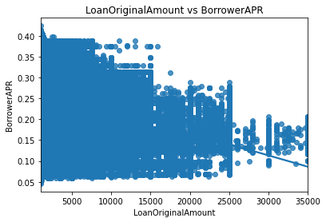

```python
sb.regplot(data = df2, x = 'LoanOriginalAmount', y = 'BorrowerAPR')
plt.title('LoanOriginalAmount vs BorrowerAPR')
```

#### There is a correlation between the LoanOriginalAmount and the BorrowerAPR that the more LoanOriginalAmount the less of BorrowerAPR

### Check if the MonthlyLoanPayment will affect on the borrower’s APR or not

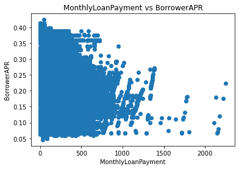

```python
plt.scatter(data = df2, x = 'MonthlyLoanPayment', y = 'BorrowerAPR')
plt.xlabel('MonthlyLoanPayment')
plt.ylabel('BorrowerAPR');
plt.title('MonthlyLoanPayment vs BorrowerAPR')
```

#### There is a correlation between the MonthlyLoanPayment and the BorrowerAPR that the less MonthlyLoanPayment the more of BorrowerAPR

### Talk about some of the relationships you observed in this part of the investigation. How did the feature(s) of interest vary with other features in the dataset?

> There is a correlation between the (MonthlyLoanPayment , LoanOriginalAmount , IncomeRange) and the BorrowerAPR

### Did you observe any interesting relationships between the other features (not the main feature(s) of interest)?

> No

## The Insights of Bivariate Exploration :

> There is a correlation between the LoanOriginalAmount and the BorrowerAPR that the more LoanOriginalAmount the less of BorrowerAPR

> There is a correlation between the MonthlyLoanPayment and the BorrowerAPR that the less MonthlyLoanPayment the more of BorrowerAPR

## Multivariate Exploration

### Check if the Term affect on the IncomeRange and BorrowerAPR

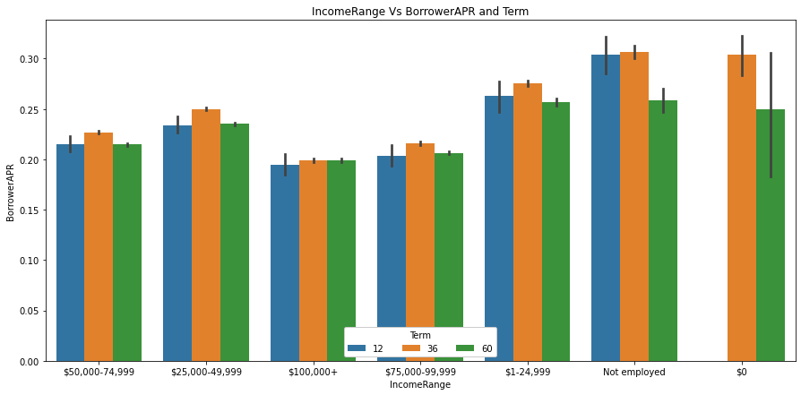

```python
plt.figure(figsize = [15, 7])

ax = sb.barplot(data = df2, x = 'IncomeRange', y = 'BorrowerAPR', hue = 'Term')
ax.legend(loc = 8, ncol = 3, framealpha = 1, title = 'Term')
plt.title('IncomeRange Vs BorrowerAPR and Term');
```

#### The term (36 monthes) have a biggest APR for all of borrowers who have an income range less than 100000 $

### Talk about some of the relationships you observed in this part of the investigation. Were there features that strengthened each other in terms of looking at your feature(s) of interest?

> The term (36 monthes) have a biggest APR for all of borrowers who have an income range less than 100000 USD